# R Notebook

### Linear and Logistic Regression Analysis

As seen in STAT 410/510, the very first machine learning model that has a root in traditional statistics is the Regression model. There are many types of regression models that can be used to model relationships between multidimensional features. The most basic types of regression are linear and logistic regression models.

In elementary statistics, simple linear regression was used between two continuous numerical features as a form of bivariate quantitiative analysis. In the real world, muultiple linear regression is more useful in modeling multidimensional numerical data. The response feature is usually continuous (example: housing prices, populations in counties, weight, height, etc.) In essence, linear regression is perfect for modeling linear relationships and making predictions.

### Multiple Linear Regression

In MLR, and for many machine learning models, we want to split our data into training and testing sets. The traditional rule is the 80-20 split (80% training and 20% testing), however in real life, this split is deterministic (up to you). For example, there have been instances where if I have a small dataset, 70-30 was a better choice, and for large datasets, I’ve used 90-10 before. Note that the main point here is to split your data where majority of your data is part of training the model and the minority part is used for validating the accuracy and appropriateness of your model.

Here, let’s consider the Boston dataset from the MASS dataset which is used in the text “Introduction to Statistical Learning with R”, where we’ll do a traditional 80-20 split and fit all the features. To do linear regression, we can use the lm() function and specify the regression formula with the ~ symbol. The response goes on the left of the ~ and your additive predictors go on the right.

```r
# install.packages("ISLR")
library(MASS)
library(ISLR)
library(rsample)
set.seed(42)

data_split = initial_split(Boston, prop=0.8)

train_data = training(data_split)
test_data = testing(data_split)

# I like doing this to check the correct split.

nrow(Boston)
```

```
## [1] 506
```

```r
nrow(train_data)
```

```
## [1] 404
```

```r
nrow(test_data)
```

```
## [1] 102
```

Here is an example with the age and lstat features, which are being used to predict medv.

```r
lm.boston = lm(medv~lstat+age, data = train_data)
summary(lm.boston)
```

```
##
## Call:
## lm(formula = medv ~ lstat + age, data = train_data)
##
## Residuals:
##     Min      1Q  Median      3Q     Max
## -15.648  -3.902  -1.184   2.163  23.466
##
## Coefficients:
##             Estimate Std. Error t value Pr(>|t|)
## (Intercept) 32.75940    0.80672   40.61  < 2e-16 ***
## lstat       -1.00799    0.05222  -19.30  < 2e-16 ***
## age          0.03380    0.01305    2.59  0.00996 **
## ---
## Signif. codes:  0 '***' 0.001 '**' 0.01 '*' 0.05 '.' 0.1 ' ' 1
##
## Residual standard error: 6.026 on 401 degrees of freedom
## Multiple R-squared:  0.547,  Adjusted R-squared:  0.5447
## F-statistic: 242.1 on 2 and 401 DF,  p-value: < 2.2e-16
```

Now to use all features in the dataset in the formula, use a “.”

```r
lm.boston = lm(medv~., data=train_data)
summary(lm.boston)
```

```
##
## Call:
## lm(formula = medv ~ ., data = train_data)
##
## Residuals:
##      Min       1Q   Median       3Q      Max
## -14.4221  -2.7174  -0.5463   1.5167  25.7788
##
## Coefficients:
##               Estimate Std. Error t value Pr(>|t|)
## (Intercept)  3.891e+01  5.736e+00   6.784 4.36e-11 ***
## crim        -1.181e-01  3.375e-02  -3.500 0.000518 ***
## zn           3.532e-02  1.599e-02   2.209 0.027760 *
## indus       -8.930e-05  6.889e-02  -0.001 0.998966
## chas         1.945e+00  9.974e-01   1.950 0.051856 .
## nox         -1.715e+01  4.258e+00  -4.028 6.77e-05 ***
## rm           3.542e+00  4.542e-01   7.797 5.85e-14 ***
## age         -3.266e-03  1.477e-02  -0.221 0.825064
## dis         -1.431e+00  2.296e-01  -6.236 1.17e-09 ***
## rad          3.031e-01  7.417e-02   4.087 5.30e-05 ***
## tax         -1.114e-02  4.227e-03  -2.636 0.008724 **
## ptratio     -9.839e-01  1.483e-01  -6.636 1.08e-10 ***
## black        8.242e-03  3.076e-03   2.680 0.007684 **
## lstat       -5.308e-01  5.514e-02  -9.627  < 2e-16 ***
## ---
## Signif. codes:  0 '***' 0.001 '**' 0.01 '*' 0.05 '.' 0.1 ' ' 1
##
## Residual standard error: 4.752 on 390 degrees of freedom
## Multiple R-squared:  0.726,  Adjusted R-squared:  0.7169
## F-statistic: 79.51 on 13 and 390 DF,  p-value: < 2.2e-16
```

To explain the output of the model summary, this tells you the coefficient estimates generated by Least Squares Optimized linear regression, which are the coefficients to your predictor features. Note that intercept in the model summary is your y-intercept of your linear regression model. To determine how good a model is, we check many things such as the R^2 foodness of fit statistic, QQ plots, plot standardized residuals, and check the Akaike Information Criterion (AIC).

The aterisks indicate the significance levels for the p-values of each of your coefficients in the model. Traditionally 0.05 is the significance level that is used, but others such as 0.01 and 0.001 can be used. P-values can be a way to carry out feature selection, the process of improving model performance by removing unnecessary features. The hypothesis test for multiple linear regression is as follows:

$$H_{0}: \beta_{i} = 0 \newline
H_{a}: \beta_{i} \neq 0$$

for some i. We reject the null hypothesis if the p-value for the coefficient is less than 0.05 and otherwise we fail to reject the null and drop the coefficient from the model.

We will see another method of feature selection via LASSO regularized regression later in this lecture.

So in the output, it looks like age, indus, and chas are insignificant since their p-values are greater than 0.05. If we rerun the model without these features, we can expect the model’s AIC to improve (smaller AIC means a better balance between features used and your goodness of fit).

```r
# To display the Analysis of Variance (ANOVA) table to check the sum of squares and which coefficients contribute most to the variance within the model and it's terms, you can use anova().

anova(lm.boston)
```

|  | Df | Sum Sq | Mean Sq | F value | Pr(>F) |
| --- | --- | --- | --- | --- | --- |
| crim | 1 | 4809.569359 | 4809.569359 | 212.9866837 | 8.466308e-39 |
| zn | 1 | 1748.417815 | 1748.417815 | 77.4268306 | 4.514056e-17 |
| indus | 1 | 2194.309258 | 2194.309258 | 97.1726608 | 1.292086e-20 |
| chas | 1 | 1061.156409 | 1061.156409 | 46.9921874 | 2.797892e-11 |
| nox | 1 | 82.456122 | 82.456122 | 3.6514820 | 5.675224e-02 |
| rm | 1 | 8169.363815 | 8169.363815 | 361.7716218 | 1.529718e-57 |
| age | 1 | 56.651101 | 56.651101 | 2.5087340 | 1.140274e-01 |
| dis | 1 | 1327.272979 | 1327.272979 | 58.7768778 | 1.419491e-13 |
| rad | 1 | 5.494772 | 5.494772 | 0.2433302 | 6.220888e-01 |
| tax | 1 | 243.862771 | 243.862771 | 10.7992045 | 1.107410e-03 |

[output cut: 4 more lines]

```r
# To check the AIC of the model, use AIC().
AIC(lm.boston)
```

```
## [1] 2421.576
```

Let’s rerun the linear regression model and see if the AIC improved. We can reruun the model by removing features with the update() function like so.

```r
lm.boston.new = update(lm.boston, .~.- age - chas - indus)
summary(lm.boston.new)
```

```
##
## Call:
## lm(formula = medv ~ crim + zn + nox + rm + dis + rad + tax +
##     ptratio + black + lstat, data = train_data)
##
## Residuals:
##      Min       1Q   Median       3Q      Max
## -12.8257  -2.7453  -0.6475   1.8036  25.4478
##
## Coefficients:
##               Estimate Std. Error t value Pr(>|t|)
## (Intercept)  39.072876   5.738079   6.809 3.68e-11 ***
## crim         -0.122017   0.033706  -3.620 0.000333 ***
## zn            0.036550   0.015687   2.330 0.020313 *
## nox         -16.831956   3.995573  -4.213 3.13e-05 ***
## rm            3.560120   0.445176   7.997 1.44e-14 ***
## dis          -1.441441   0.211812  -6.805 3.78e-11 ***
## rad           0.317158   0.070505   4.498 9.03e-06 ***
## tax          -0.011812   0.003744  -3.155 0.001730 **
## ptratio      -1.001553   0.147456  -6.792 4.10e-11 ***
## black         0.008454   0.003071   2.753 0.006180 **
## lstat        -0.540805   0.052080 -10.384  < 2e-16 ***
## ---
## Signif. codes:  0 '***' 0.001 '**' 0.01 '*' 0.05 '.' 0.1 ' ' 1
##
## Residual standard error: 4.757 on 393 degrees of freedom
## Multiple R-squared:  0.7233, Adjusted R-squared:  0.7163
## F-statistic: 102.7 on 10 and 393 DF,  p-value: < 2.2e-16
```

```r
AIC(lm.boston.new)
```

```
## [1] 2419.554
```

And our AIC decreased so we now have a better model.

In regression analysis, we typically want to find the “best model”. To check this in addition to AIC checks, we want to plot the residuals and standardized residuals.

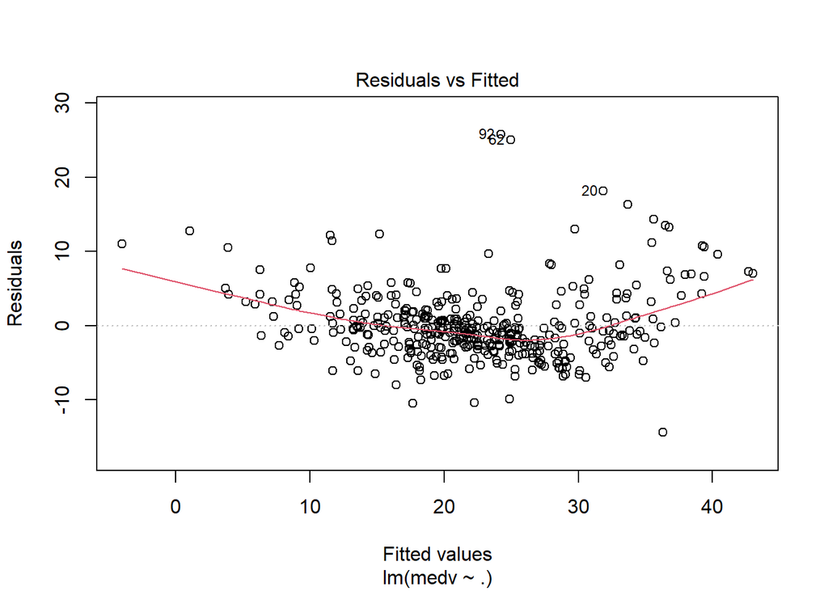

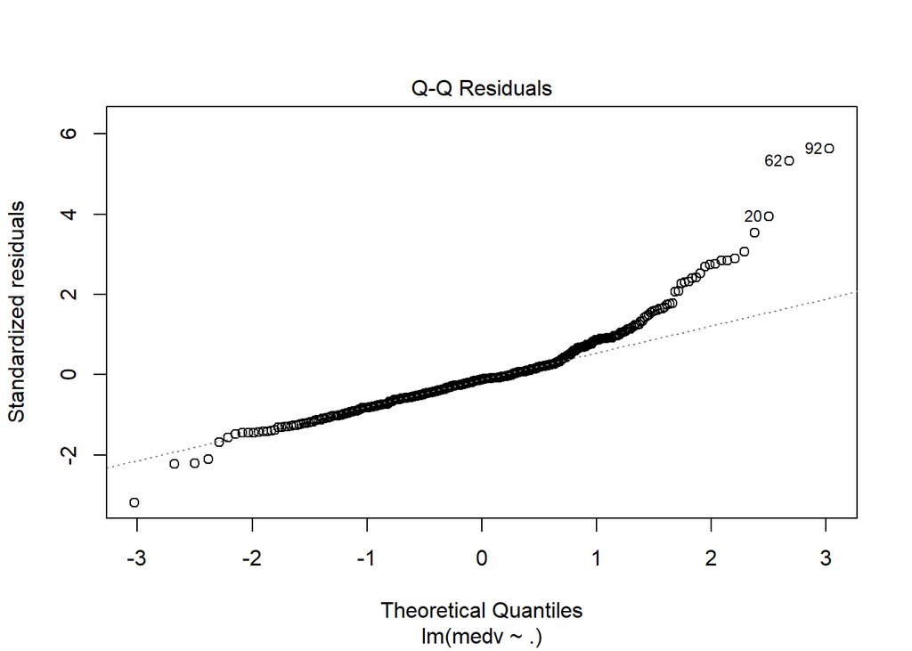

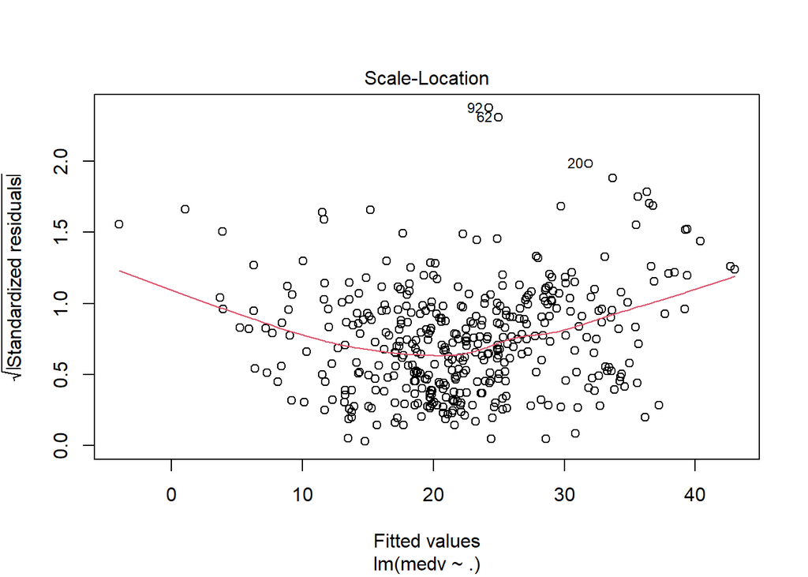

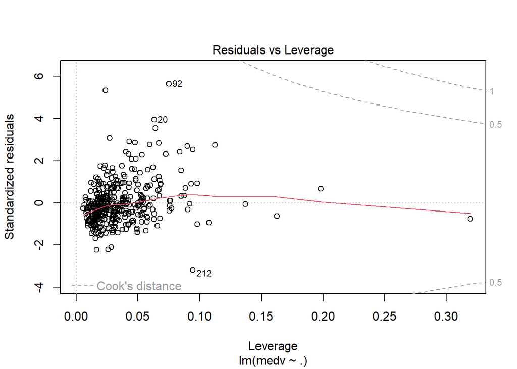

```r
plot(lm.boston)
```

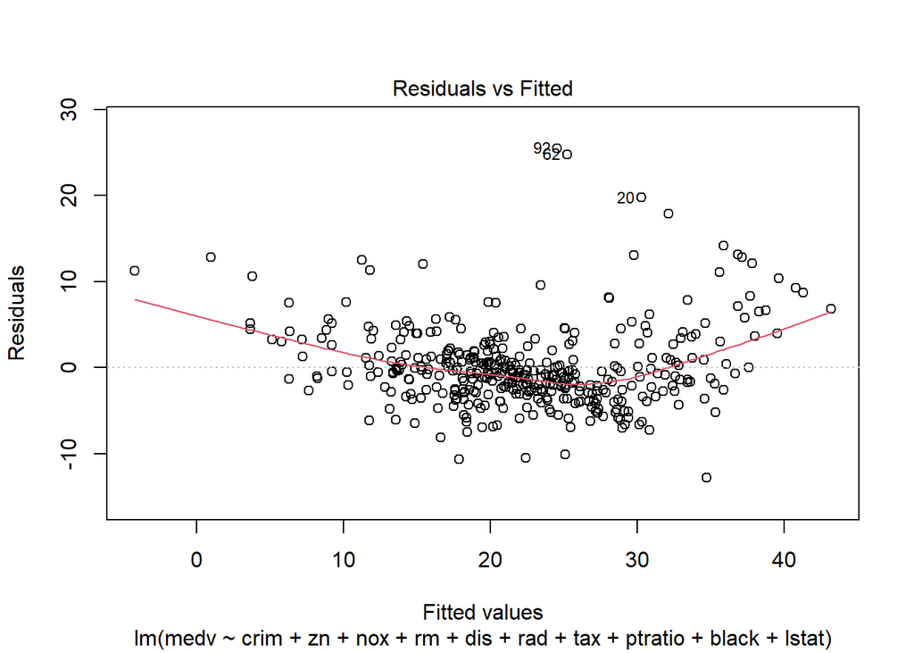

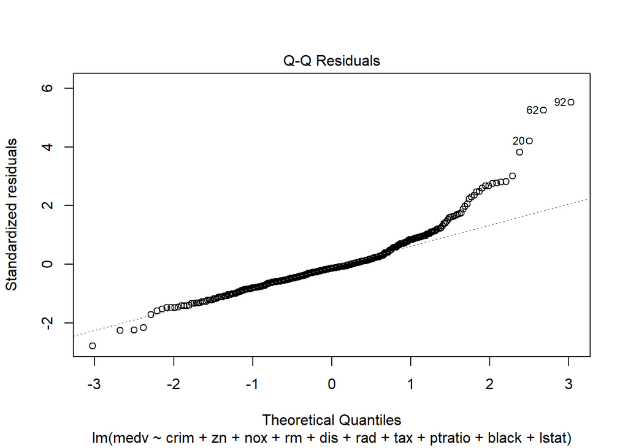

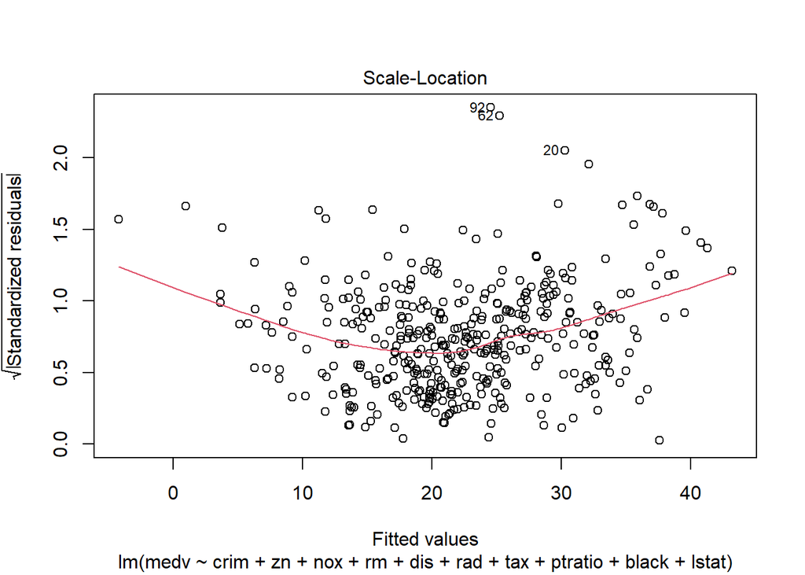

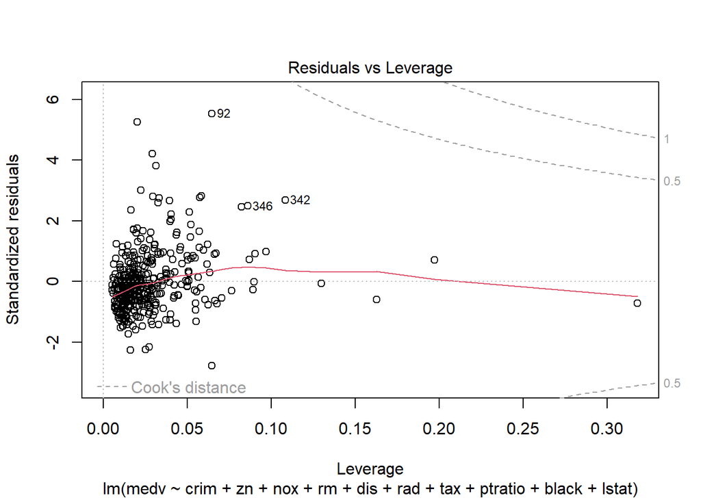

```r
plot(lm.boston.new)
```

Thus we have done what’s called “model checking and validation”. Now, I will show you the non-theoretic application of what’s called regularized regression.

Regularized regression comes in three flavors: LASSO, Ridge, and Elastic Net. The idea here is to start with a base model, and place penalties on terms to diagnose which ones to remove. LASSO does this in the L1 norm, Ridge does this in the L2 norm, and Elastic Net does this in the L1 and L2 norms. For simplicity, we’ll only consider LASSO for this class, but I encourage you look into the other methods, which is typically covered in STAT 473: Statistical Machine Learning.

LASSO regression penalizes the sum of absolute values of your model’s coefficients, which means that it places penalties on your coefficients to drive them to zero (disappearing magic trick). This is the conceptual understanding of the technique, I will not go into advanced theory here. Here’s the way to do it:

```r
# install.packages("glmnet")
library(glmnet)
```

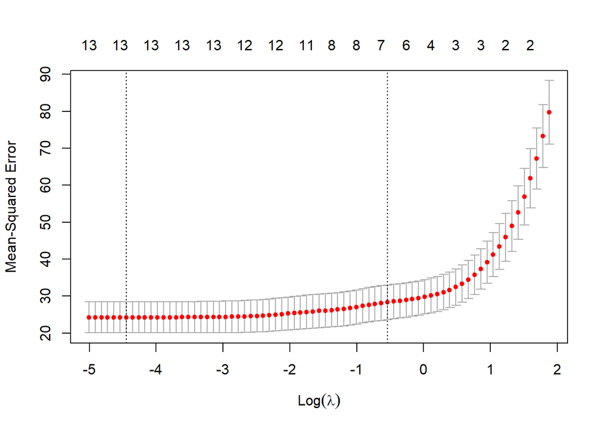

```r
set.seed(42)

# Split the data into predictor and response matrices.

x = model.matrix(medv~., train_data)[,-1]
y = train_data$medv

# use the cross validation for glmnet to find the best lambda parameter to perform LASSO regression. use alpha=1 for LASSO and alpha=2 for Ridge.

cv_lasso = cv.glmnet(x, y, alpha=1, nfolds=10)
best_lambda = cv_lasso$lambda.min
plot(cv_lasso)
```

```r
best_lambda
```

```
## [1] 0.0117183
```

Now we run the final model on the data using the best alpha and display the coefficients.

```r
final_lm_lasso = glmnet(x, y, alpha=1, lambda=best_lambda)
coef(final_lm_lasso)
```

```
## 14 x 1 sparse Matrix of class "dgCMatrix"
##                        s0
## (Intercept)  38.037076380
## crim         -0.113932892
## zn            0.033007430
## indus        -0.003337341
## chas          1.941910449
## nox         -16.684951157
## rm            3.564485937
## age          -0.002484846
## dis          -1.384335930
## rad           0.280953696
## tax          -0.010147846
## ptratio      -0.976541153
## black         0.008145773
## lstat        -0.531632513
```

Data in real life can be messy, so you may need to create different subsets of your linear models by considering nonlinear terms such as quadratic or power terms. To deal with finding optimal models raised to nonlinear powers, you can use Boxcox transformations to normalize your data and its residuals, covered in STAT 410/510 in greater detail.

To make predictions with your model, you can use the predict function on the testing data.

```r
predictions.linear = predict(lm.boston.new, newdata=test_data)
predictions.linear[1:10]
```

```
##        1        2        3        4        5        6        7        8
## 23.39792 19.77529 21.30039 19.48387 17.05465 16.60154 12.64524 15.84168
##        9       10
## 13.67271 19.59157
```

### Logistic Regression

Now, what if our response feature isn’t continuous numeric, but a binary numeric/categorical variable (whether a patient has a disease or not)? We would need to consider a special generalized linear model (GLM) called Logistic Regression. The difference here is that we would need to use the glm() function.

Another main difference between Linear Regression and Logistic Regression is that linear regression uses the identity function f(x)=x as its link function while logistic regression uses the the logistic function f(x) = ln(x/(1-x)). The link function of a generalized linear model relates the mean of the response variable to a linear combination of the predictor features. For now, let’s see how we can carry out logistic regression to classify data with binary response features on the Stock Market dataset from the ISLR package.

```r
library(ISLR)

names(Smarket)
```

```
## [1] "Year"      "Lag1"      "Lag2"      "Lag3"      "Lag4"      "Lag5"
## [7] "Volume"    "Today"     "Direction"
```

```r
dim(Smarket)
```

```
## [1] 1250    9
```

```r
summary(Smarket)
```

```
##       Year           Lag1                Lag2                Lag3
##  Min.   :2001   Min.   :-4.922000   Min.   :-4.922000   Min.   :-4.922000
##  1st Qu.:2002   1st Qu.:-0.639500   1st Qu.:-0.639500   1st Qu.:-0.640000
##  Median :2003   Median : 0.039000   Median : 0.039000   Median : 0.038500
##  Mean   :2003   Mean   : 0.003834   Mean   : 0.003919   Mean   : 0.001716
##  3rd Qu.:2004   3rd Qu.: 0.596750   3rd Qu.: 0.596750   3rd Qu.: 0.596750
##  Max.   :2005   Max.   : 5.733000   Max.   : 5.733000   Max.   : 5.733000
##       Lag4                Lag5              Volume           Today
##  Min.   :-4.922000   Min.   :-4.92200   Min.   :0.3561   Min.   :-4.922000
##  1st Qu.:-0.640000   1st Qu.:-0.64000   1st Qu.:1.2574   1st Qu.:-0.639500
##  Median : 0.038500   Median : 0.03850   Median :1.4229   Median : 0.038500
##  Mean   : 0.001636   Mean   : 0.00561   Mean   :1.4783   Mean   : 0.003138
##  3rd Qu.: 0.596750   3rd Qu.: 0.59700   3rd Qu.:1.6417   3rd Qu.: 0.596750
##  Max.   : 5.733000   Max.   : 5.73300   Max.   :3.1525   Max.   : 5.733000
##  Direction
##  Down:602
##  Up  :648
##
##
##
##
```

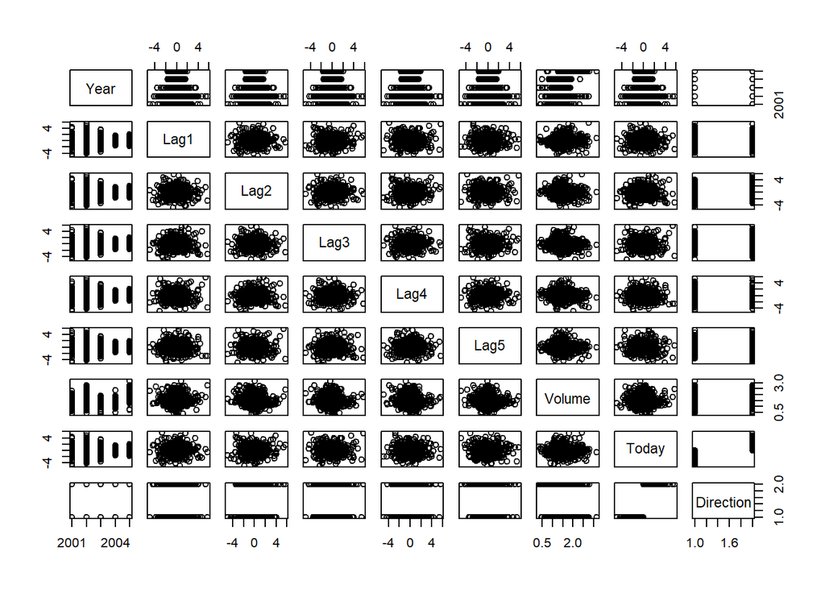

```r
# The direction feature is qualitative so we drop it before using cor(). We can do this by indexing the dataset by -9 to retrieve the last 9 features.

pairs(Smarket)
```

```r
cor(Smarket[,-9])
```

```
##              Year         Lag1         Lag2         Lag3         Lag4
## Year   1.00000000  0.029699649  0.030596422  0.033194581  0.035688718
## Lag1   0.02969965  1.000000000 -0.026294328 -0.010803402 -0.002985911
## Lag2   0.03059642 -0.026294328  1.000000000 -0.025896670 -0.010853533
## Lag3   0.03319458 -0.010803402 -0.025896670  1.000000000 -0.024051036
## Lag4   0.03568872 -0.002985911 -0.010853533 -0.024051036  1.000000000
## Lag5   0.02978799 -0.005674606 -0.003557949 -0.018808338 -0.027083641
## Volume 0.53900647  0.040909908 -0.043383215 -0.041823686 -0.048414246
## Today  0.03009523 -0.026155045 -0.010250033 -0.002447647 -0.006899527
##                Lag5      Volume        Today
## Year    0.029787995  0.53900647  0.030095229
## Lag1   -0.005674606  0.04090991 -0.026155045
## Lag2   -0.003557949 -0.04338321 -0.010250033
## Lag3   -0.018808338 -0.04182369 -0.002447647
## Lag4   -0.027083641 -0.04841425 -0.006899527
## Lag5    1.000000000 -0.02200231 -0.034860083
## Volume -0.022002315  1.00000000  0.014591823
## Today  -0.034860083  0.01459182  1.000000000
```

For this example, we will predict direction (either up or down hence it is binary) using the lags and stock volume features in the dataset.

```r
set.seed(42)

stock_split = initial_split(Smarket, prop=0.8)

train.data.stock = training(stock_split)
test.data.stock = testing(stock_split)

logistic.stock = glm(Direction~Lag1+Lag2+Lag3+Lag4+Lag5+Volume, data=train.data.stock, family=binomial)
summary(logistic.stock)
```

```
##
## Call:
## glm(formula = Direction ~ Lag1 + Lag2 + Lag3 + Lag4 + Lag5 +
##     Volume, family = binomial, data = train.data.stock)
##
## Coefficients:
##              Estimate Std. Error z value Pr(>|z|)
## (Intercept) -0.245371   0.265573  -0.924   0.3555
## Lag1        -0.111518   0.057697  -1.933   0.0533 .
## Lag2        -0.055049   0.057434  -0.958   0.3378
## Lag3         0.005788   0.057967   0.100   0.9205
## Lag4         0.041642   0.057412   0.725   0.4683
## Lag5         0.058075   0.057482   1.010   0.3123
## Volume       0.218631   0.173533   1.260   0.2077
## ---
## Signif. codes:  0 '***' 0.001 '**' 0.01 '*' 0.05 '.' 0.1 ' ' 1
##
## (Dispersion parameter for binomial family taken to be 1)
##
##     Null deviance: 1384.7  on 999  degrees of freedom
## Residual deviance: 1377.1  on 993  degrees of freedom
## AIC: 1391.1
##
## Number of Fisher Scoring iterations: 4
```

```r
coef(logistic.stock)
```

```
##  (Intercept)         Lag1         Lag2         Lag3         Lag4         Lag5
## -0.245370843 -0.111518419 -0.055048693  0.005788449  0.041642402  0.058074976
##       Volume
##  0.218631447
```

Now since we have the coefficients of the logistic regression model, we can predict the probability of the levels of our response feature. In this case, we can predict whether the stock will go up or not. We can do this by using the predict() function and specifying ‘type=response’.

```r
stock.probs = predict(logistic.stock, type="response")

# First 10 probabilities of the stock market going up

stock.probs[1:10]
```

```
##         1         2         3         4         5         6         7         8
## 0.5569553 0.5383190 0.5648688 0.5438049 0.5188692 0.4905344 0.5148313 0.5341230
##         9        10
## 0.4690200 0.5341915
```

To predict for a particular day, we convert the probabilities to class labels by specifying a binary threshold. Here, any probability greater than 0.5 will be classified as “up” and otherwise “down”.

```r
stock.pred = rep("Down", nrow(train.data.stock))
stock.pred[stock.probs>0.5] = "Up"

# Based on the predicted probabilities, will the stock market go up or down on the 50th day? The 100th day?

stock.pred[50]
```

```
## [1] "Up"
```

```r
stock.pred[100]
```

```
## [1] "Down"
```

Since logistic regression is a classification model, we can compute the accuracy of the model. We have actually calculated the accuracy of a mock classification model in the beginning of the semester with a for loop structure. Here, we can take the mean of all predictions that match with the true values from the dataset.

Alternatively, we can output what’s called the “confusion matrix” of the model which gives us the classifications as True Positives, False Positives, True Negatives, and False Negatives. To compute accuracy, add up the main diagonal of the matrix and divide by the total number of rows.

```r
stock.acc = mean(stock.pred==train.data.stock$Direction)

# Confusion Matrix

table(stock.pred, train.data.stock$Direction)
```

```
##
## stock.pred Down  Up
##       Down  156 141
##       Up    324 379
```

```r
stock.acc2 = (156+379) / nrow(train.data.stock)

stock.acc
```

```
## [1] 0.535
```

```r
stock.acc2
```

```
## [1] 0.535
```